# IODS course project

Leo Aarnio

# Introduction to Open Data Science - Course Project

*This course is a practical introduction to open data science directed to the PhD student. Having completed the course, the student is to be equipped with the understanding, tools and methods to employ the principles of open science in his daily work.*

# About the project

The project displayed in what follows concerns statistical analysis done with a plethora of techniques useful in gaining a quantitative understanding of the phenomena we are to probe into. We will go through linear and logistic regression, clustering and classification, dimensionality reduction and longitudinal analysis.

Here is a link to my github repository that holds the contents of the analysis:

https://github.com/ltjaarni/IODS-project

```r
date()
```

```
## [1] "Mon Dec 11 16:31:57 2023"
```

I am excited to learn more R Markdown and the use of Git. I found the course by browsing through the course catalogue for the general studies -module for PhD students and found this course to be among the most relevant and interesting on offer.

I find the approach of the course to be very topical and am looking forward to learning more about the principles and practices of open data and open science. This is the direction I believe science to be heading towards: sharing openly all that can be safely shared with regards the epistemically important steps in reaching the inferences one draws in any published study. In general, this can be understood as a way to boost the self-correcting mechanism of science, for instance through its reproducibility, an issue I believe to be of utmost interest specifically now with the many challenges that have been recently revealed regarding how dubiously these processes currently operate.

Handling uncertainty by appropriate statistical methods is only the tip of the iceberg here. *There are plenty epistemically important steps taken that tend to remain hidden and that cannot be accounted for within-model alone*: the entire process from experimental design to conclusions involve decisions the logic of which it is important to ground in any scientific report, and this implies having to be explicit about such choices in a way that they, too, are made open to the public scrutiny of scientific peers.

On an even more general note, I believe the entire philosophy on the conduct of science to be in need of drastic rethinking. This means, first and foremost, taking scientific agenthood seriously so that the scientist takes direct accountability for all the epistemically important choices he makes in the process of inference. I believe we have a history of more than a century of a misguided ideal to shake here, where many of the choices clearly dependent on one’s judgement are masked as non-choices, as if they were objective and uncontested: came upon the scientist conceived of as a passive observer of reality in and of itself. One manifestation of this is the downright fallacious mode of writing scientific text in a passive tone: inescapable states of affairs being forced upon the scientist as if he was not the one actually conducting them. This entire outlook should be turned on its head: science is not about mirroring reality, but about building a case constrained by it. Science ought comprise of making a convincing argument to an overt objective of inference backed up by plausible reasoning the scientist himself is accountable for seriously grounding.

# A case study in linear regression

*In the following, we will explore, with a rough explanatory and predictive model,* *the association that approaches and study skills to learning as well as attitudes towards* *statistics have on exam performance in statistics.*

The explanatory variables concerning approaches to studying and study skills are based on a shortened version of a standardized measure called ASSIST (Approaches and Study Skills Inventory for Students) and the explanatory variables concerning attitudes towards statistics are based on SATS (Survey of Attitudes Toward Statistics). We construct composite measures on the attitude, a deep approach to learning, a surface approach to learning and a strategic approach to learning that are based on the mean of original questionnaire items on each of these dimensions. We will treat our integer-valued target variable as if it were a continuous, real-valued variable, and use a linear regression model to explain and predict the score with these composite dimensions as explanatory variables.

```
## [1] "Mon Dec 11 16:31:58 2023"
```

We first read in an analysis dataset we have already preprocessed.

```r
# We require the library readr

library(readr)

# Read the file into the workspace
learning2014<-read_csv("~/Intro_to_ODS/IODS/data/learning2014.csv")
# Check the head and structure of the data
str(learning2014)
```

```
## spec_tbl_df [166 x 7] (S3: spec_tbl_df/tbl_df/tbl/data.frame)
##  $ gender  : chr [1:166] "F" "M" "F" "M" ...
##  $ age     : num [1:166] 53 55 49 53 49 38 50 37 37 42 ...
##  $ attitude: num [1:166] 3.7 3.1 2.5 3.5 3.7 3.8 3.5 2.9 3.8 2.1 ...
##  $ deep    : num [1:166] 3.58 2.92 3.5 3.5 3.67 ...
##  $ stra    : num [1:166] 3.38 2.75 3.62 3.12 3.62 ...
##  $ surf    : num [1:166] 2.58 3.17 2.25 2.25 2.83 ...
##  $ points  : num [1:166] 25 12 24 10 22 21 21 31 24 26 ...
##  - attr(*, "spec")=
##   .. cols(
##   ..   gender = col_character(),
##   ..   age = col_double(),
##   ..   attitude = col_double(),
##   ..   deep = col_double(),
##   ..   stra = col_double(),
##   ..   surf = col_double(),
##   ..   points = col_double()
##   .. )
##  - attr(*, "problems")=<externalptr>
```

```r
head(learning2014)
```

```
## # A tibble: 6 x 7
##   gender   age attitude  deep  stra  surf points
##   <chr>  <dbl>    <dbl> <dbl> <dbl> <dbl>  <dbl>
## 1 F         53      3.7  3.58  3.38  2.58     25
## 2 M         55      3.1  2.92  2.75  3.17     12
## 3 F         49      2.5  3.5   3.62  2.25     24
## 4 M         53      3.5  3.5   3.12  2.25     10
## 5 M         49      3.7  3.67  3.62  2.83     22
## 6 F         38      3.8  4.75  3.62  2.42     21
```

The data has 166 observations on 7 variables: “gender”, “age”, “attitude”, “deep”, “stra”, “surf” and “points”. Gender is a character vector that is a categorical variable and the others are numeric, with age and points integer-valued (absolute scale) and the rest interval-scaled (the interpretation being that there is no natural 0 for attitude nor the approaches to learning, and that since we have averaged the original items in deriving the composite measures, we have already treated these items as if they were at least interval-valued, even if measured on a Likert-scale more befitting, strictly speaking, of an ordinal interpretation). “Attitude”, “deep”, “stra” and “surf” are composite measures on attitudes towards statistics, deep, strategic and surface approach to learning, respectively. “Points” is our primary outcome variable of interest that measures the score on a statistics exam.

Let us take a brief look at the data with a quick visual. We use gender as a partitioning variable for displaying the one-against-one associations (scatter plots and correlation coefficients) and the kernels of all the other variables in our analysis dataset.

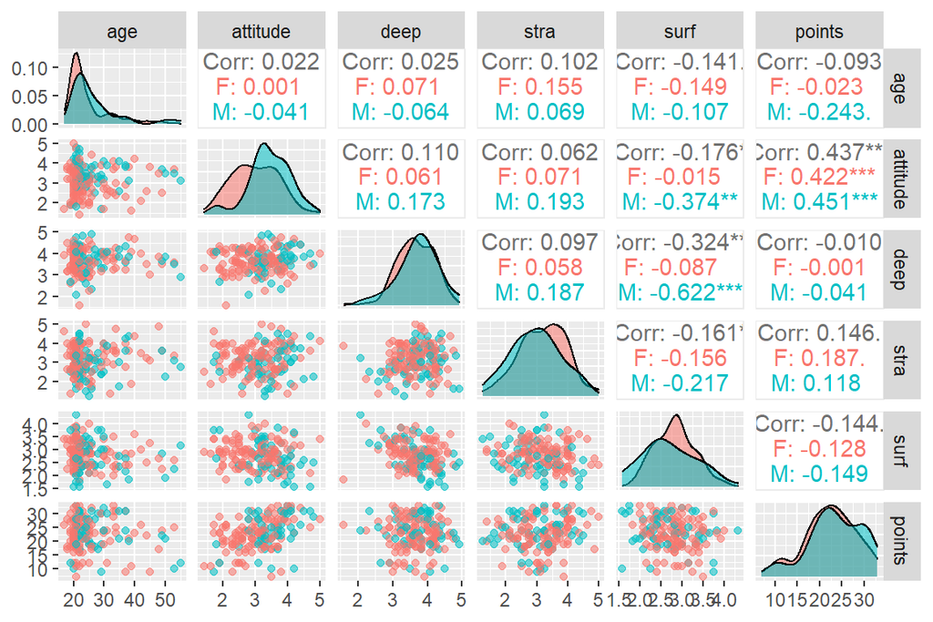

```r
# We require GGally and ggplot2 libraries for our visuals
library(GGally)
library(ggplot2)

# Create a plot matrix with ggpairs()
p <- ggpairs(learning2014[-1], mapping = aes(col=learning2014$gender, alpha=0.3), lower = list(combo = wrap("facethist", bins = 20)))

# draw the plot
p
```

Also of interest is the fact that the surface approach to learning is correlated with attitude, deep approach and strategic approach to learning (it seems intuitive from the name that it ought indeed be negatively correlated with the deep approach). This means that if we decided to include the surface approach as an explanatory variable in our regression model, we should be on the lookout for multicollinearity.

Some other descriptive observations of interest from our plot are that men seem to score better on attitude, whereas women have a higher score on the surface and the strategic approach to learning. Also, it is of interest that there seems to be very little difference between the genders in terms of exam performance – risking an overinterpretation made from but an estimated density plot, the bump in men’s performance in the right-tail of the points density might indicate they have a higher probability than women of scoring extremely well in the exam. In terms of demographics, we may note that most students are young and roughly in their twenties.

Since the association between attitude and points is the one clearly popping out, let us look at a larger visual of the scatter plot with a fitted regression line.

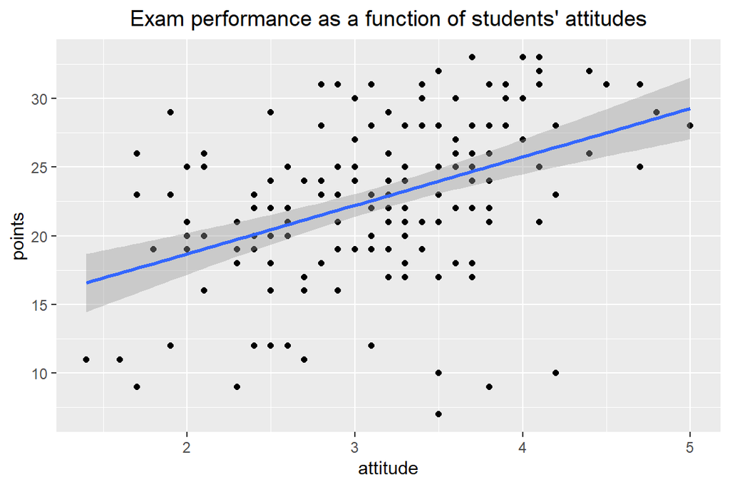

```r
# We require ggplot for our visual
library(ggplot2)

# iOnitialize plot with data and aesthetic mapping
p1 <- ggplot(learning2014, aes(x = attitude, y = points))

# Define the visualization type (points)
p2 <- p1 + geom_point()

# Add a regression line
p3 <- p2 + geom_smooth(method = "lm")

# Add a main title
p4 <- p3 + ggtitle("Exam performance as a function of students' attitudes") + theme(plot.title = element_text(hjust = 0.5))

# Draw the plot
p4
```

The fitted regession line and its 95% confidence band confirm what is already visible from the scatter plot to the naked eye: there is a clear positive correlation between attitude and exam performance. When looking at the singular questionnaire items that we have utilized in deriving the composite attitude measure, this association makes perfect sense.

The confidence band widens when moving towards both ends of the composite attitude measure, since we have less observations with very high and very low overall score.

Let us also look at some basic summary statistics of each variable of interest before moving forward.

```r
summary(learning2014,digits=3)
```

```
##     gender               age          attitude         deep           stra
##  Length:166         Min.   :17.0   Min.   :1.40   Min.   :1.58   Min.   :1.25
##  Class :character   1st Qu.:21.0   1st Qu.:2.60   1st Qu.:3.33   1st Qu.:2.62
##  Mode  :character   Median :22.0   Median :3.20   Median :3.67   Median :3.19
##                     Mean   :25.5   Mean   :3.14   Mean   :3.68   Mean   :3.12
##                     3rd Qu.:27.0   3rd Qu.:3.70   3rd Qu.:4.08   3rd Qu.:3.62
##                     Max.   :55.0   Max.   :5.00   Max.   :4.92   Max.   :5.00
##       surf          points
##  Min.   :1.58   Min.   : 7.0
##  1st Qu.:2.42   1st Qu.:19.0
##  Median :2.83   Median :23.0
##  Mean   :2.79   Mean   :22.7
##  3rd Qu.:3.17   3rd Qu.:27.8
##  Max.   :4.33   Max.   :33.0
```

If we were interested in predictive performance – as opposed to constructing some theory-laden model and interpreting it against this theoretical background – we might be inclined to choose, as an initial model, one that included those predictor variables with the highest absolute values of their correlation coefficient point estimates with our outcome variable of interest. So let us start there and compile a regression model with (an intercept term and) the predictor variables “attitude”, “stra” and “surf” (ordered here in a decreasing order of the absolute value of the point estimates for their correlation coefficients).

```r
# Fit regression model with three variables as predictors
my_model3 <- lm(points ~ attitude + stra + surf, data = learning2014)

# print out a summary of the model
summary(my_model3)
```

```
##
## Call:
## lm(formula = points ~ attitude + stra + surf, data = learning2014)
##
## Residuals:
##      Min       1Q   Median       3Q      Max
## -17.1550  -3.4346   0.5156   3.6401  10.8952
##
## Coefficients:
##             Estimate Std. Error t value Pr(>|t|)
## (Intercept)  11.0171     3.6837   2.991  0.00322 **
## attitude      3.3952     0.5741   5.913 1.93e-08 ***
## stra          0.8531     0.5416   1.575  0.11716
## surf         -0.5861     0.8014  -0.731  0.46563
## ---
## Signif. codes:  0 '***' 0.001 '**' 0.01 '*' 0.05 '.' 0.1 ' ' 1
##
## Residual standard error: 5.296 on 162 degrees of freedom
## Multiple R-squared:  0.2074, Adjusted R-squared:  0.1927
## F-statistic: 14.13 on 3 and 162 DF,  p-value: 3.156e-08
```

We have a linear regression model of the following form:

$y_i=b_0 + b_1x_i + b_2x_i + b_3x_i + \epsilon_i$,

where $i$ indexes the observations, and where we let the regression coefficients be numbered so that they denote, in an ascending order by their index, the intercept, attitude, stra and surf, respectively.

We assume that the error terms $\epsilon$ are normally distributed with mean zero and have a constant variance across different values for the explanatory variables.

We use ordinary least-squares to estimate our regression terms. We see that the point estimate for $b_1$, $\hat{b_1}$, is roughly 3.4, with a standard error of roughly 0.6. So a unit increase in attitude is associated with a roughly 2- to 5-fold increase in the expected score of the exam, with our best estimate a 3.4-fold increase. This is a substantial increase given that the score has a range from 7 to 33 and the attitude a range from 1.4 to 5. Based on the t-test, the data is incompatible with the null of “no effect” (a coefficient of zero), with a highly significant p-value of 0.00000002. We get the t-value by dividing the regression coefficient point estimate by its standard error, and then the p-value for the two-sided test from the t-distribution with 162 degrees of freedom.

Given that the estimate for the regression coefficient of one of our explanatory variables is incompatible with the null of no effect, it is unsurprising that the omnibus test for the null that all coefficients are nil has a very small p-value based on the F-test. Our multiple R-squared is estimated at 0.21, which means that roughly 20% percent of the variation of the exam score can be explained by the explanatory variables. With but such a simple model, this is a decent, if still a relatively low value. The adjusted R-squared value, that penalizes a more complex model for its count of explanatory variables, suggests that a more parsimonious model would perhaps be recommendable, as does the fact that two of our regression coefficients are not statistically significant. We are nonetheless somewhat tempted to let “stra” remain in the model, since its relatively high p-value does not necessarily imply it is entirely redundant (this depends on the overall model, and we have correlation between “stra” and “surf”), so we decide to explore what happens if we first drop only “surf” from the overall model.

```r
# create a regression model with multiple explanatory variables
my_model2 <- lm(points ~ attitude + stra, data = learning2014)

# print out a summary of the model
summary(my_model2)
```

```
##
## Call:
## lm(formula = points ~ attitude + stra, data = learning2014)
##
## Residuals:
##      Min       1Q   Median       3Q      Max
## -17.6436  -3.3113   0.5575   3.7928  10.9295
##
## Coefficients:
##             Estimate Std. Error t value Pr(>|t|)
## (Intercept)   8.9729     2.3959   3.745  0.00025 ***
## attitude      3.4658     0.5652   6.132 6.31e-09 ***
## stra          0.9137     0.5345   1.709  0.08927 .
## ---
## Signif. codes:  0 '***' 0.001 '**' 0.01 '*' 0.05 '.' 0.1 ' ' 1
##
## Residual standard error: 5.289 on 163 degrees of freedom
## Multiple R-squared:  0.2048, Adjusted R-squared:  0.1951
## F-statistic: 20.99 on 2 and 163 DF,  p-value: 7.734e-09
```

We observe that there are no considerable differences to the above in terms of our explanatory variable “attitude”, and relatively minor changes to that of “stra”, although its t-value increases by a small margin. Our multiple R-squared decreases by a very small amount, and our adjusted R-squared increases by a very small amount. We decide to further drop “stra”, which remains statistically non-significant in our reduced model.

```r
# create a regression model with multiple explanatory variables
my_model3 <- lm(points ~ attitude, data = learning2014)

# print out a summary of the model
summary(my_model3)
```

```
##
## Call:
## lm(formula = points ~ attitude, data = learning2014)
##
## Residuals:
##      Min       1Q   Median       3Q      Max
## -16.9763  -3.2119   0.4339   4.1534  10.6645
##
## Coefficients:
##             Estimate Std. Error t value Pr(>|t|)
## (Intercept)  11.6372     1.8303   6.358 1.95e-09 ***
## attitude      3.5255     0.5674   6.214 4.12e-09 ***
## ---
## Signif. codes:  0 '***' 0.001 '**' 0.01 '*' 0.05 '.' 0.1 ' ' 1
##
## Residual standard error: 5.32 on 164 degrees of freedom
## Multiple R-squared:  0.1906, Adjusted R-squared:  0.1856
## F-statistic: 38.61 on 1 and 164 DF,  p-value: 4.119e-09
```

The interpretation of the association of “attitude” with that of the exam score remains as before, since there are no notable changes in our estimates concerning the explanatory variable in question.